# Extending the Four Basic Designs

Prof Randi Garcia  
April 4, 2018

### Announcements

- Adriana Colom Cruz, Lab Instructor candidate, talk/demo today 12:00-1:00p in Bass 103 (Pizza will be served!)
- [Women in Statistics and Data Science Conference](http://ww2.amstat.org/meetings/wsds/2018/abstractsubmission/index.cfm)
  - Submit and anstract by **April 19th**
  - Conference is October 18-October 20 in Cincinnati, Ohio
  - SDS can maybe give you travel money!
- HW 7 is due today at 5pm
- Project data collection should start soon!

### Agenda

- Split plot designs
- Analysis in R
- Extending designs by factorial crossing

### Residuals in the LS design (redux)

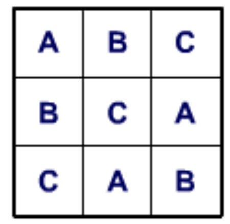

### Split Plot/Repeated Measures Design

- Can use **split plot** language if blocking is created by sud-dividing blocks (whole plot and subplot factors)
- We can use the **repeated measures** language if blocking is created by reusing subjects/material (within and between subjects factors)
- We can always use the terms **blocks** and **within-blocks** terminology

### Split Plot Design

If you suspect a design in a split-plot design, you should be able to answer the following questions:

1. What are the whole plots, that is, what is the nuisance factor?
2. What is the between-blocks factor? Is it observational or experimental?
3. What is the within-blocks factor? Is it observational or experimental?

### Example from HW7: Parsnip Plants

### Diabetic Dogs

The disease diabetes affects the rate of turnover of lactic acid in a system of biochemical reactions called the Cori cycle. This experiment compares two methods of using radioactive carbon-14 to measure rate of turnover. Method 1 is injection all at once, and method 2 is infused continuously. 10 dogs were sorted into two groups, 5 were controls and 5 had their pancreas removed (to make it diabetic). The rate of turnover was then measured twice for each dog, once for each method. The order of the two methods was randomly assigned.

Draw the factor diagram for the data on page 263.

### Crossing versus Nesting

1. **Crossing**: Two sets of treatments are crossed if all possible combinations of treatments occur in the design. The design is called a two-way factorial and has factorial treatment structure.
2. **Nesting**: One factor is nested within another if each level of the first (“inside”) factor occurs with exactly one level of the second (“outside”) factor.

### Algebraic Notation for the Spilt Plot Design

\[ {y}_{ijk}={\mu}+{\alpha}_{i}+{\beta}_{ij}+{\gamma}_{k}+({\alpha\gamma})_{ik}+{e}_{ijk} \]

- \( {\mu} \) is the benchmark
- \( {\alpha}_{i} \) effect of level i of the between-blocks factor, \( i \) from \( 1 \) to \( a \)
- \( {\beta}_{j(i)} \) effect of block \( j \) (for level \( i \) of the within block factor), \( j \) from \( 1 \) to \( n \)
- \( {\gamma}_{k} \) effect of level \( k \) of the within-block factor, \( k \) from \( 1 \) to \( t \)
- \( ({\alpha\gamma})_{ik} \) interaction efefct for level \( i \) of the between-blocks factor with level \( k \) of the within-blocks factor

### Formal ANOVA for the Spilt Plot Design

| Source | SS | df | MS | F |
| --- | --- | --- | --- | --- |
| Between | \( \sum_{i=1}^{a}n(\bar{y}_{i..}-\bar{y}_{...})^{2} \) | \( a-1 \) | \( \frac{{SS}_{A}}{{df}_{A}} \) | \( \frac{{MS}_{A}}{{MS}_{B}} \) |
| Blocks | \( t\sum_{i=1}^{a}\sum_{j=1}^{n}(\bar{y}_{ij.}-\bar{y}_{i..})^{2} \) | \( N-a \) | \( \frac{{SS}_{B}}{{df}_{B}} \) | \( \frac{{MS}_{B}}{{MS}_{E}} \) |
| Within | \( \sum_{k=1}^{t}n(\bar{y}_{..k}-\bar{y}_{...})^{2} \) | \( t-1 \) | \( \frac{{SS}_{T}}{{df}_{T}} \) | \( \frac{{MS}_{T}}{{MS}_{E}} \) |
| Interaction | \( \sum_{i=1}^{a}\sum_{k=1}^{t}\frac{N}{a}(\bar{y}_{i.k}-\bar{y}_{i..}-\bar{y}_{..k}+\bar{y}_{...})^{2} \) | \( (a-1)(t-1) \) | \( \frac{{SS}_{AT}}{{df}_{AT}} \) | \( \frac{{MS}_{AT}}{{MS}_{E}} \) |
| Error | \( \sum_{i=1}^{a}\sum_{j=1}^{N}\sum_{k=1}^{t}({y}_{ijk}-\bar{y}_{i.k}-\bar{y}_{.j.}-\bar{y}_{..k}+\bar{y}_{i..})^{2} \) | \( (N-a)(t-1) \) | \( \frac{{SS}_{E}}{{df}_{E}} \) |  |